# Bellabeat Case Study

2023-10-02

# **Case Study 2**

## **1.Summary**

Bellabeat is a company that specializes in manufacturing high-tech smart products for women’s health. Their range of smart devices collects data on various aspects such as activity, sleep, stress, and reproductive health. The goal of Bellabeat is to empower women by providing them with insights and knowledge about their own health and habits.

In this case, our focus is on analyzing the fitness data collected by Bellabeat’s smart devices. We aim to identify potential growth opportunities for the company. Specifically, we will be examining the Bellabeat app, which serves as a platform for users to access their health data. Through the app, users can track their activity, sleep patterns, stress levels, menstrual cycle, and mindfulness habits. This valuable data enables users to gain a deeper understanding of their current habits and make informed decisions to improve their overall health and well-being. Additionally, the Bellabeat app seamlessly integrates with other smart wellness products offered by the company.

## **2. Ask**

### **2.1 Business Task**

The objective of this analysis is to identify patterns and trends in consumer usage of non-Bellabeat smart devices, in order to inform and enhance Bellabeat’s marketing strategy and drive growth in the smart health products market for women.

### **2.2 Stakeholders**

**Urška Sršen**: Bellabeat’s cofounder and Chief Creative Officer **Sando Mur**: Mathematician and Bellabeat’s cofounder; key member of the Bellabeat executive team **Bellabeat marketing analytics team**: A team of data analysts responsible for collecting, analyzing, and reporting data that helps guide Bellabeat’s marketing strategy.

## **3. Prepare**

### **3.1 Dataset used:**

The data source used for our case study is FitBit Fitness Tracker Data. This dataset is stored in Kaggle and was made available through Mobius.

### **3.2 Accessibility and privacy of data:**

Verifying the metadata of our dataset we can confirm it is open-source. The owner has dedicated the work to the public domain by waiving all of his or her rights to the work worldwide under copyright law, including all related and neighboring rights, to the extent allowed by law. You can copy, modify, distribute and perform the work, even for commercial purposes, all without asking permission.

### **3.4 Data Organization and verification:**

Available to us are 18 CSV documents. Each document represents different quantitative data tracked by Fitbit. The data is considered long since each row is one time point per subject, so each subject will have data in multiple rows.Every user has a unique ID and different rows since data is tracked by day and time.

I mainly used RStudio for cleaning and preparation.

## **4. Process**

This analysis is done in Rstudio using R programming language. R is very versatile an has the ability to clean, analyze and visualize the Data.

### **4.1 Installing packages and opening libraries**

We will use the following packages for our analysis:

```r
install.packages("tidyverse")
install.packages("skimr")
install.packages("janitor")
install.packages("ggpubr")
install.packages("here")
install.packages("lubridate")
install.packages("ggrepel")
```

Opening the libraries:

```r
library(ggpubr)
library(tidyverse)
library(here)
library(skimr)
library(janitor)
library(lubridate)
library(ggrepel)
```

### **4.2 Importing datasets**

I will upload the datasets that will help me answer the business task. On my analysis I will focus on the following datasets:

- dailyActivity
- sleepDay
- dailyIntensity
- dailyCalories
- hourlySteps

```r
daily_activity <- read_csv("dailyActivity_merged.csv")
daily_intensity <- read_csv("dailyIntensities_merged.csv")
daily_sleep <- read_csv("sleepDay_merged.csv")
hourly_steps <- read_csv("hourlySteps_merged.csv")
daily_calories <- read_csv("dailyCalories_merged.csv")
```

### **4.3 Getting to know the data**

Now we’ll get a little sneak peak at our chosen datasets.

```r
head(daily_activity)
```

```
## # A tibble: 6 × 15
##           Id ActivityDate TotalSteps TotalDistance TrackerDistance
##        <dbl> <chr>             <dbl>         <dbl>           <dbl>
## 1 1503960366 4/12/2016         13162          8.5             8.5
## 2 1503960366 4/13/2016         10735          6.97            6.97
## 3 1503960366 4/14/2016         10460          6.74            6.74
## 4 1503960366 4/15/2016          9762          6.28            6.28
## 5 1503960366 4/16/2016         12669          8.16            8.16
## 6 1503960366 4/17/2016          9705          6.48            6.48
## # ℹ 10 more variables: LoggedActivitiesDistance <dbl>,
## #   VeryActiveDistance <dbl>, ModeratelyActiveDistance <dbl>,
## #   LightActiveDistance <dbl>, SedentaryActiveDistance <dbl>,
## #   VeryActiveMinutes <dbl>, FairlyActiveMinutes <dbl>,
## #   LightlyActiveMinutes <dbl>, SedentaryMinutes <dbl>, Calories <dbl>
```

```r
str(daily_activity)
```

```
## spc_tbl_ [940 × 15] (S3: spec_tbl_df/tbl_df/tbl/data.frame)
##  $ Id                      : num [1:940] 1.5e+09 1.5e+09 1.5e+09 1.5e+09 1.5e+09 ...
##  $ ActivityDate            : chr [1:940] "4/12/2016" "4/13/2016" "4/14/2016" "4/15/2016" ...
##  $ TotalSteps              : num [1:940] 13162 10735 10460 9762 12669 ...
##  $ TotalDistance           : num [1:940] 8.5 6.97 6.74 6.28 8.16 ...
##  $ TrackerDistance         : num [1:940] 8.5 6.97 6.74 6.28 8.16 ...
##  $ LoggedActivitiesDistance: num [1:940] 0 0 0 0 0 0 0 0 0 0 ...
##  $ VeryActiveDistance      : num [1:940] 1.88 1.57 2.44 2.14 2.71 ...
##  $ ModeratelyActiveDistance: num [1:940] 0.55 0.69 0.4 1.26 0.41 ...
##  $ LightActiveDistance     : num [1:940] 6.06 4.71 3.91 2.83 5.04 ...
##  $ SedentaryActiveDistance : num [1:940] 0 0 0 0 0 0 0 0 0 0 ...
##  $ VeryActiveMinutes       : num [1:940] 25 21 30 29 36 38 42 50 28 19 ...
##  $ FairlyActiveMinutes     : num [1:940] 13 19 11 34 10 20 16 31 12 8 ...
##  $ LightlyActiveMinutes    : num [1:940] 328 217 181 209 221 164 233 264 205 211 ...
##  $ SedentaryMinutes        : num [1:940] 728 776 1218 726 773 ...
##  $ Calories                : num [1:940] 1985 1797 1776 1745 1863 ...
##  - attr(*, "spec")=
##   .. cols(
##   ..   Id = col_double(),
##   ..   ActivityDate = col_character(),
##   ..   TotalSteps = col_double(),
##   ..   TotalDistance = col_double(),
##   ..   TrackerDistance = col_double(),
##   ..   LoggedActivitiesDistance = col_double(),
##   ..   VeryActiveDistance = col_double(),
##   ..   ModeratelyActiveDistance = col_double(),
##   ..   LightActiveDistance = col_double(),
##   ..   SedentaryActiveDistance = col_double(),
##   ..   VeryActiveMinutes = col_double(),
##   ..   FairlyActiveMinutes = col_double(),
##   ..   LightlyActiveMinutes = col_double(),
##   ..   SedentaryMinutes = col_double(),
##   ..   Calories = col_double()
##   .. )
##  - attr(*, "problems")=<externalptr>
```

```r
head(daily_intensity)
```

```
## # A tibble: 6 × 10
##         Id ActivityDay SedentaryMinutes LightlyActiveMinutes FairlyActiveMinutes
##      <dbl> <chr>                  <dbl>                <dbl>               <dbl>
## 1   1.50e9 4/12/2016                728                  328                  13
## 2   1.50e9 4/13/2016                776                  217                  19
## 3   1.50e9 4/14/2016               1218                  181                  11
## 4   1.50e9 4/15/2016                726                  209                  34
## 5   1.50e9 4/16/2016                773                  221                  10
## 6   1.50e9 4/17/2016                539                  164                  20
## # ℹ 5 more variables: VeryActiveMinutes <dbl>, SedentaryActiveDistance <dbl>,
## #   LightActiveDistance <dbl>, ModeratelyActiveDistance <dbl>,
## #   VeryActiveDistance <dbl>
```

```r
str(daily_intensity)
```

```
## spc_tbl_ [940 × 10] (S3: spec_tbl_df/tbl_df/tbl/data.frame)
##  $ Id                      : num [1:940] 1.5e+09 1.5e+09 1.5e+09 1.5e+09 1.5e+09 ...
##  $ ActivityDay             : chr [1:940] "4/12/2016" "4/13/2016" "4/14/2016" "4/15/2016" ...
##  $ SedentaryMinutes        : num [1:940] 728 776 1218 726 773 ...
##  $ LightlyActiveMinutes    : num [1:940] 328 217 181 209 221 164 233 264 205 211 ...
##  $ FairlyActiveMinutes     : num [1:940] 13 19 11 34 10 20 16 31 12 8 ...
##  $ VeryActiveMinutes       : num [1:940] 25 21 30 29 36 38 42 50 28 19 ...
##  $ SedentaryActiveDistance : num [1:940] 0 0 0 0 0 0 0 0 0 0 ...
##  $ LightActiveDistance     : num [1:940] 6.06 4.71 3.91 2.83 5.04 ...
##  $ ModeratelyActiveDistance: num [1:940] 0.55 0.69 0.4 1.26 0.41 ...
##  $ VeryActiveDistance      : num [1:940] 1.88 1.57 2.44 2.14 2.71 ...
##  - attr(*, "spec")=
##   .. cols(
##   ..   Id = col_double(),
##   ..   ActivityDay = col_character(),
##   ..   SedentaryMinutes = col_double(),
##   ..   LightlyActiveMinutes = col_double(),
##   ..   FairlyActiveMinutes = col_double(),
##   ..   VeryActiveMinutes = col_double(),
##   ..   SedentaryActiveDistance = col_double(),
##   ..   LightActiveDistance = col_double(),
##   ..   ModeratelyActiveDistance = col_double(),
##   ..   VeryActiveDistance = col_double()
##   .. )
##  - attr(*, "problems")=<externalptr>
```

```r
head(daily_sleep)
```

```
## # A tibble: 6 × 5
##           Id SleepDay        TotalSleepRecords TotalMinutesAsleep TotalTimeInBed
##        <dbl> <chr>                       <dbl>              <dbl>          <dbl>
## 1 1503960366 4/12/2016 12:0…                 1                327            346
## 2 1503960366 4/13/2016 12:0…                 2                384            407
## 3 1503960366 4/15/2016 12:0…                 1                412            442
## 4 1503960366 4/16/2016 12:0…                 2                340            367
## 5 1503960366 4/17/2016 12:0…                 1                700            712
## 6 1503960366 4/19/2016 12:0…                 1                304            320
```

```r
str(daily_sleep)
```

```
## spc_tbl_ [413 × 5] (S3: spec_tbl_df/tbl_df/tbl/data.frame)
##  $ Id                : num [1:413] 1.5e+09 1.5e+09 1.5e+09 1.5e+09 1.5e+09 ...
##  $ SleepDay          : chr [1:413] "4/12/2016 12:00:00 AM" "4/13/2016 12:00:00 AM" "4/15/2016 12:00:00 AM" "4/16/2016 12:00:00 AM" ...
##  $ TotalSleepRecords : num [1:413] 1 2 1 2 1 1 1 1 1 1 ...
##  $ TotalMinutesAsleep: num [1:413] 327 384 412 340 700 304 360 325 361 430 ...
##  $ TotalTimeInBed    : num [1:413] 346 407 442 367 712 320 377 364 384 449 ...
##  - attr(*, "spec")=
##   .. cols(
##   ..   Id = col_double(),
##   ..   SleepDay = col_character(),
##   ..   TotalSleepRecords = col_double(),
##   ..   TotalMinutesAsleep = col_double(),
##   ..   TotalTimeInBed = col_double()
##   .. )
##  - attr(*, "problems")=<externalptr>
```

```r
head(hourly_steps)
```

```
## # A tibble: 6 × 3
##           Id ActivityHour          StepTotal
##        <dbl> <chr>                     <dbl>
## 1 1503960366 4/12/2016 12:00:00 AM       373
## 2 1503960366 4/12/2016 1:00:00 AM        160
## 3 1503960366 4/12/2016 2:00:00 AM        151
## 4 1503960366 4/12/2016 3:00:00 AM          0
## 5 1503960366 4/12/2016 4:00:00 AM          0
## 6 1503960366 4/12/2016 5:00:00 AM          0
```

```r
str(hourly_steps)
```

```
## spc_tbl_ [22,099 × 3] (S3: spec_tbl_df/tbl_df/tbl/data.frame)
##  $ Id          : num [1:22099] 1.5e+09 1.5e+09 1.5e+09 1.5e+09 1.5e+09 ...
##  $ ActivityHour: chr [1:22099] "4/12/2016 12:00:00 AM" "4/12/2016 1:00:00 AM" "4/12/2016 2:00:00 AM" "4/12/2016 3:00:00 AM" ...
##  $ StepTotal   : num [1:22099] 373 160 151 0 0 ...
##  - attr(*, "spec")=
##   .. cols(
##   ..   Id = col_double(),
##   ..   ActivityHour = col_character(),
##   ..   StepTotal = col_double()
##   .. )
##  - attr(*, "problems")=<externalptr>
```

```r
head(daily_calories)
```

```
## # A tibble: 6 × 3
##           Id ActivityDay Calories
##        <dbl> <chr>          <dbl>
## 1 1503960366 4/12/2016       1985
## 2 1503960366 4/13/2016       1797
## 3 1503960366 4/14/2016       1776
## 4 1503960366 4/15/2016       1745
## 5 1503960366 4/16/2016       1863
## 6 1503960366 4/17/2016       1728
```

```r
str(daily_calories)
```

```
## spc_tbl_ [940 × 3] (S3: spec_tbl_df/tbl_df/tbl/data.frame)
##  $ Id         : num [1:940] 1.5e+09 1.5e+09 1.5e+09 1.5e+09 1.5e+09 ...
##  $ ActivityDay: chr [1:940] "4/12/2016" "4/13/2016" "4/14/2016" "4/15/2016" ...
##  $ Calories   : num [1:940] 1985 1797 1776 1745 1863 ...
##  - attr(*, "spec")=
##   .. cols(
##   ..   Id = col_double(),
##   ..   ActivityDay = col_character(),
##   ..   Calories = col_double()
##   .. )
##  - attr(*, "problems")=<externalptr>
```

### **4.4 Cleaning and formatting the data**

First I checked the number of unique users on every dataset:

```r
n_unique(daily_activity$Id)
```

```
## [1] 33
```

```r
n_unique(daily_intensity$Id)
```

```
## [1] 33
```

```r
n_unique(daily_sleep$Id)
```

```
## [1] 24
```

```r
n_unique(hourly_steps$Id)
```

```
## [1] 33
```

```r
n_unique(daily_calories$Id)
```

```
## [1] 33
```

Then I find out the number of duplicates in each dataset:

```r
sum(duplicated(daily_activity))
```

```
## [1] 0
```

```r
sum(duplicated(daily_intensity))
```

```
## [1] 0
```

```r
sum(duplicated(daily_sleep))
```

```
## [1] 3
```

```r
sum(duplicated(hourly_steps))
```

```
## [1] 0
```

```r
sum(duplicated(daily_calories))
```

```
## [1] 0
```

Only the daily_sleep dataset contains duplicates. The next code chunk removes the duplicates.

```r
daily_sleep <- daily_sleep %>%
  distinct() %>%
  drop_na()

sum(duplicated(daily_sleep))
```

```
## [1] 0
```

Now, I format the column names across all datasets to lowercase.

```r
clean_names(daily_activity)
```

```
## # A tibble: 940 × 15
##            id activity_date total_steps total_distance tracker_distance
##         <dbl> <chr>               <dbl>          <dbl>            <dbl>
##  1 1503960366 4/12/2016           13162           8.5              8.5
##  2 1503960366 4/13/2016           10735           6.97             6.97
##  3 1503960366 4/14/2016           10460           6.74             6.74
##  4 1503960366 4/15/2016            9762           6.28             6.28
##  5 1503960366 4/16/2016           12669           8.16             8.16
##  6 1503960366 4/17/2016            9705           6.48             6.48
##  7 1503960366 4/18/2016           13019           8.59             8.59
##  8 1503960366 4/19/2016           15506           9.88             9.88
##  9 1503960366 4/20/2016           10544           6.68             6.68
## 10 1503960366 4/21/2016            9819           6.34             6.34
## # ℹ 930 more rows
## # ℹ 10 more variables: logged_activities_distance <dbl>,
## #   very_active_distance <dbl>, moderately_active_distance <dbl>,
## #   light_active_distance <dbl>, sedentary_active_distance <dbl>,
## #   very_active_minutes <dbl>, fairly_active_minutes <dbl>,
## #   lightly_active_minutes <dbl>, sedentary_minutes <dbl>, calories <dbl>
```

```r
daily_activity<- rename_with(daily_activity, tolower)
clean_names(daily_sleep)
```

```
## # A tibble: 410 × 5
##          id sleep_day total_sleep_records total_minutes_asleep total_time_in_bed
##       <dbl> <chr>                   <dbl>                <dbl>             <dbl>
##  1   1.50e9 4/12/201…                   1                  327               346
##  2   1.50e9 4/13/201…                   2                  384               407
##  3   1.50e9 4/15/201…                   1                  412               442
##  4   1.50e9 4/16/201…                   2                  340               367
##  5   1.50e9 4/17/201…                   1                  700               712
##  6   1.50e9 4/19/201…                   1                  304               320
##  7   1.50e9 4/20/201…                   1                  360               377
##  8   1.50e9 4/21/201…                   1                  325               364
##  9   1.50e9 4/23/201…                   1                  361               384
## 10   1.50e9 4/24/201…                   1                  430               449
## # ℹ 400 more rows
```

```r
daily_sleep <- rename_with(daily_sleep, tolower)
clean_names(daily_intensity)
```

```
## # A tibble: 940 × 10
##            id activity_day sedentary_minutes lightly_active_minutes
##         <dbl> <chr>                    <dbl>                  <dbl>
##  1 1503960366 4/12/2016                  728                    328
##  2 1503960366 4/13/2016                  776                    217
##  3 1503960366 4/14/2016                 1218                    181
##  4 1503960366 4/15/2016                  726                    209
##  5 1503960366 4/16/2016                  773                    221
##  6 1503960366 4/17/2016                  539                    164
##  7 1503960366 4/18/2016                 1149                    233
##  8 1503960366 4/19/2016                  775                    264
##  9 1503960366 4/20/2016                  818                    205
## 10 1503960366 4/21/2016                  838                    211
## # ℹ 930 more rows
## # ℹ 6 more variables: fairly_active_minutes <dbl>, very_active_minutes <dbl>,
## #   sedentary_active_distance <dbl>, light_active_distance <dbl>,
## #   moderately_active_distance <dbl>, very_active_distance <dbl>
```

```r
daily_intensity<- rename_with(daily_intensity, tolower)
clean_names(daily_calories)
```

```
## # A tibble: 940 × 3
##            id activity_day calories
##         <dbl> <chr>           <dbl>
##  1 1503960366 4/12/2016        1985
##  2 1503960366 4/13/2016        1797
##  3 1503960366 4/14/2016        1776
##  4 1503960366 4/15/2016        1745
##  5 1503960366 4/16/2016        1863
##  6 1503960366 4/17/2016        1728
##  7 1503960366 4/18/2016        1921
##  8 1503960366 4/19/2016        2035
##  9 1503960366 4/20/2016        1786
## 10 1503960366 4/21/2016        1775
## # ℹ 930 more rows
```

```r
daily_calories <- rename_with(daily_calories, tolower)
clean_names(hourly_steps)
```

```
## # A tibble: 22,099 × 3
##            id activity_hour         step_total
##         <dbl> <chr>                      <dbl>
##  1 1503960366 4/12/2016 12:00:00 AM        373
##  2 1503960366 4/12/2016 1:00:00 AM         160
##  3 1503960366 4/12/2016 2:00:00 AM         151
##  4 1503960366 4/12/2016 3:00:00 AM           0
##  5 1503960366 4/12/2016 4:00:00 AM           0
##  6 1503960366 4/12/2016 5:00:00 AM           0
##  7 1503960366 4/12/2016 6:00:00 AM           0
##  8 1503960366 4/12/2016 7:00:00 AM           0
##  9 1503960366 4/12/2016 8:00:00 AM         250
## 10 1503960366 4/12/2016 9:00:00 AM        1864
## # ℹ 22,089 more rows
```

```r
hourly_steps <- rename_with(hourly_steps, tolower)
```

Formatting Time/Date Cloumns across all datasets for consistency.

```r
daily_activity <- daily_activity %>%
  rename(date = activitydate) %>%
  mutate(date = as_date(date, format = "%m/%d/%Y"))

daily_sleep <- daily_sleep %>%
  rename(date = sleepday) %>%
  mutate(date = as_date(date,format ="%m/%d/%Y %I:%M:%S %p" , tz=Sys.timezone()))
daily_intensity <- daily_intensity %>%
  rename(date = activityday) %>%
  mutate(date = as_date(date, format = "%m/%d/%Y"))

daily_calories <- daily_calories %>%
  rename(date = activityday) %>%
  mutate(date = as_date(date,format ="%m/%d/%Y" , tz=Sys.timezone()))
hourly_steps<- hourly_steps %>%
  rename(date_time = activityhour) %>%
  mutate(date_time = as.POSIXct(date_time,format ="%m/%d/%Y %I:%M:%S %p" , tz=Sys.timezone()))

head(daily_activity)
```

```
## # A tibble: 6 × 15
##           id date       totalsteps totaldistance trackerdistance
##        <dbl> <date>          <dbl>         <dbl>           <dbl>
## 1 1503960366 2016-04-12      13162          8.5             8.5
## 2 1503960366 2016-04-13      10735          6.97            6.97
## 3 1503960366 2016-04-14      10460          6.74            6.74
## 4 1503960366 2016-04-15       9762          6.28            6.28
## 5 1503960366 2016-04-16      12669          8.16            8.16
## 6 1503960366 2016-04-17       9705          6.48            6.48
## # ℹ 10 more variables: loggedactivitiesdistance <dbl>,
## #   veryactivedistance <dbl>, moderatelyactivedistance <dbl>,
## #   lightactivedistance <dbl>, sedentaryactivedistance <dbl>,
## #   veryactiveminutes <dbl>, fairlyactiveminutes <dbl>,
## #   lightlyactiveminutes <dbl>, sedentaryminutes <dbl>, calories <dbl>
```

```r
head(daily_sleep)
```

```
## # A tibble: 6 × 5
##           id date       totalsleeprecords totalminutesasleep totaltimeinbed
##        <dbl> <date>                 <dbl>              <dbl>          <dbl>
## 1 1503960366 2016-04-12                 1                327            346
## 2 1503960366 2016-04-13                 2                384            407
## 3 1503960366 2016-04-15                 1                412            442
## 4 1503960366 2016-04-16                 2                340            367
## 5 1503960366 2016-04-17                 1                700            712
## 6 1503960366 2016-04-19                 1                304            320
```

```r
head(daily_intensity)
```

```
## # A tibble: 6 × 10
##          id date       sedentaryminutes lightlyactiveminutes fairlyactiveminutes
##       <dbl> <date>                <dbl>                <dbl>               <dbl>
## 1    1.50e9 2016-04-12              728                  328                  13
## 2    1.50e9 2016-04-13              776                  217                  19
## 3    1.50e9 2016-04-14             1218                  181                  11
## 4    1.50e9 2016-04-15              726                  209                  34
## 5    1.50e9 2016-04-16              773                  221                  10
## 6    1.50e9 2016-04-17              539                  164                  20
## # ℹ 5 more variables: veryactiveminutes <dbl>, sedentaryactivedistance <dbl>,
## #   lightactivedistance <dbl>, moderatelyactivedistance <dbl>,
## #   veryactivedistance <dbl>
```

```r
head(daily_calories)
```

```
## # A tibble: 6 × 3
##           id date       calories
##        <dbl> <date>        <dbl>
## 1 1503960366 2016-04-12     1985
## 2 1503960366 2016-04-13     1797
## 3 1503960366 2016-04-14     1776
## 4 1503960366 2016-04-15     1745
## 5 1503960366 2016-04-16     1863
## 6 1503960366 2016-04-17     1728
```

```r
head(hourly_steps)
```

```
## # A tibble: 6 × 3
##           id date_time           steptotal
##        <dbl> <dttm>                  <dbl>
## 1 1503960366 2016-04-12 00:00:00       373
## 2 1503960366 2016-04-12 01:00:00       160
## 3 1503960366 2016-04-12 02:00:00       151
## 4 1503960366 2016-04-12 03:00:00         0
## 5 1503960366 2016-04-12 04:00:00         0
## 6 1503960366 2016-04-12 05:00:00         0
```

### **4.5 Summarizing and Merging Datasets**

First, I get the summary of each dataset to further understand the data.

```r
daily_activity %>%
  select(totalsteps,
         totaldistance,
         sedentaryminutes,
         calories) %>%
  summary()
```

```
##    totalsteps    totaldistance    sedentaryminutes    calories
##  Min.   :    0   Min.   : 0.000   Min.   :   0.0   Min.   :   0
##  1st Qu.: 3790   1st Qu.: 2.620   1st Qu.: 729.8   1st Qu.:1828
##  Median : 7406   Median : 5.245   Median :1057.5   Median :2134
##  Mean   : 7638   Mean   : 5.490   Mean   : 991.2   Mean   :2304
##  3rd Qu.:10727   3rd Qu.: 7.713   3rd Qu.:1229.5   3rd Qu.:2793
##  Max.   :36019   Max.   :28.030   Max.   :1440.0   Max.   :4900
```

```r
daily_activity %>%
  select(veryactiveminutes, fairlyactiveminutes, lightlyactiveminutes) %>%
  summary()
```

```
##  veryactiveminutes fairlyactiveminutes lightlyactiveminutes
##  Min.   :  0.00    Min.   :  0.00      Min.   :  0.0
##  1st Qu.:  0.00    1st Qu.:  0.00      1st Qu.:127.0
##  Median :  4.00    Median :  6.00      Median :199.0
##  Mean   : 21.16    Mean   : 13.56      Mean   :192.8
##  3rd Qu.: 32.00    3rd Qu.: 19.00      3rd Qu.:264.0
##  Max.   :210.00    Max.   :143.00      Max.   :518.0
```

```r
daily_calories %>%
  select(calories) %>%
  summary()
```

```
##     calories
##  Min.   :   0
##  1st Qu.:1828
##  Median :2134
##  Mean   :2304
##  3rd Qu.:2793
##  Max.   :4900
```

```r
daily_sleep %>%
  select(totalsleeprecords, totalminutesasleep, totaltimeinbed) %>%
  summary()
```

```
##  totalsleeprecords totalminutesasleep totaltimeinbed
##  Min.   :1.00      Min.   : 58.0      Min.   : 61.0
##  1st Qu.:1.00      1st Qu.:361.0      1st Qu.:403.8
##  Median :1.00      Median :432.5      Median :463.0
##  Mean   :1.12      Mean   :419.2      Mean   :458.5
##  3rd Qu.:1.00      3rd Qu.:490.0      3rd Qu.:526.0
##  Max.   :3.00      Max.   :796.0      Max.   :961.0
```

```r
daily_intensity %>%
  select(sedentaryminutes, lightlyactiveminutes, fairlyactiveminutes, veryactiveminutes) %>%
  summary()
```

```
##  sedentaryminutes lightlyactiveminutes fairlyactiveminutes veryactiveminutes
##  Min.   :   0.0   Min.   :  0.0        Min.   :  0.00      Min.   :  0.00
##  1st Qu.: 729.8   1st Qu.:127.0        1st Qu.:  0.00      1st Qu.:  0.00
##  Median :1057.5   Median :199.0        Median :  6.00      Median :  4.00
##  Mean   : 991.2   Mean   :192.8        Mean   : 13.56      Mean   : 21.16
##  3rd Qu.:1229.5   3rd Qu.:264.0        3rd Qu.: 19.00      3rd Qu.: 32.00
##  Max.   :1440.0   Max.   :518.0        Max.   :143.00      Max.   :210.00
```

**Some interesting findings from this summary include:**

- The average sedentary time is 991 minutes or 16 hours, which is a **high amount** and should be **reduced.**
- The majority of participants are lightly active, indicating that they **may not be engaging in enough physical activity.**
- On average, participants sleep once for 7 hours, suggesting that they are getting a decent amount of sleep.
- The average total steps per day are 7638, which is slightly below the recommended level for health benefits according to CDC research. The CDC found that taking 8,000 steps per day was associated with a 51% lower risk of all-cause mortality, while taking 12,000 steps per day was associated with a 65% lower risk compared to taking only 4,000 steps.

Next, I merge some datasets to analyze for insights:

```r
daily_activity_sleep <- merge(daily_activity, daily_sleep, by=c ("id", "date"))
glimpse(daily_activity_sleep)
```

```
## Rows: 410
## Columns: 18
## $ id                       <dbl> 1503960366, 1503960366, 1503960366, 150396036…
## $ date                     <date> 2016-04-12, 2016-04-13, 2016-04-15, 2016-04-…
## $ totalsteps               <dbl> 13162, 10735, 9762, 12669, 9705, 15506, 10544…
## $ totaldistance            <dbl> 8.50, 6.97, 6.28, 8.16, 6.48, 9.88, 6.68, 6.3…
## $ trackerdistance          <dbl> 8.50, 6.97, 6.28, 8.16, 6.48, 9.88, 6.68, 6.3…
## $ loggedactivitiesdistance <dbl> 0, 0, 0, 0, 0, 0, 0, 0, 0, 0, 0, 0, 0, 0, 0, …
## $ veryactivedistance       <dbl> 1.88, 1.57, 2.14, 2.71, 3.19, 3.53, 1.96, 1.3…
## $ moderatelyactivedistance <dbl> 0.55, 0.69, 1.26, 0.41, 0.78, 1.32, 0.48, 0.3…
## $ lightactivedistance      <dbl> 6.06, 4.71, 2.83, 5.04, 2.51, 5.03, 4.24, 4.6…
## $ sedentaryactivedistance  <dbl> 0, 0, 0, 0, 0, 0, 0, 0, 0, 0, 0, 0, 0, 0, 0, …
## $ veryactiveminutes        <dbl> 25, 21, 29, 36, 38, 50, 28, 19, 41, 39, 73, 3…
## $ fairlyactiveminutes      <dbl> 13, 19, 34, 10, 20, 31, 12, 8, 21, 5, 14, 23,…
## $ lightlyactiveminutes     <dbl> 328, 217, 209, 221, 164, 264, 205, 211, 262, …
## $ sedentaryminutes         <dbl> 728, 776, 726, 773, 539, 775, 818, 838, 732, …
## $ calories                 <dbl> 1985, 1797, 1745, 1863, 1728, 2035, 1786, 177…
## $ totalsleeprecords        <dbl> 1, 2, 1, 2, 1, 1, 1, 1, 1, 1, 1, 1, 1, 1, 1, …
## $ totalminutesasleep       <dbl> 327, 384, 412, 340, 700, 304, 360, 325, 361, …
## $ totaltimeinbed           <dbl> 346, 407, 442, 367, 712, 320, 377, 364, 384, …
```

```r
daily_average <- daily_activity_sleep %>%
  group_by(id) %>%
  summarise (mean_daily_steps = mean(totalsteps), mean_daily_calories = mean(calories), mean_daily_sleep = mean(totalminutesasleep))

head(daily_average)
```

```
## # A tibble: 6 × 4
##           id mean_daily_steps mean_daily_calories mean_daily_sleep
##        <dbl>            <dbl>               <dbl>            <dbl>
## 1 1503960366           12406.               1872.             360.
## 2 1644430081            7968.               2978.             294
## 3 1844505072            3477                1676.             652
## 4 1927972279            1490                2316.             417
## 5 2026352035            5619.               1541.             506.
## 6 2320127002            5079                1804               61
```

```r
daily_intensity_sleep <- merge(daily_intensity, daily_sleep, by=c ("id", "date"))
glimpse(daily_intensity_sleep)
```

```
## Rows: 410
## Columns: 13
## $ id                       <dbl> 1503960366, 1503960366, 1503960366, 150396036…
## $ date                     <date> 2016-04-12, 2016-04-13, 2016-04-15, 2016-04-…
## $ sedentaryminutes         <dbl> 728, 776, 726, 773, 539, 775, 818, 838, 732, …
## $ lightlyactiveminutes     <dbl> 328, 217, 209, 221, 164, 264, 205, 211, 262, …
## $ fairlyactiveminutes      <dbl> 13, 19, 34, 10, 20, 31, 12, 8, 21, 5, 14, 23,…
## $ veryactiveminutes        <dbl> 25, 21, 29, 36, 38, 50, 28, 19, 41, 39, 73, 3…
## $ sedentaryactivedistance  <dbl> 0, 0, 0, 0, 0, 0, 0, 0, 0, 0, 0, 0, 0, 0, 0, …
## $ lightactivedistance      <dbl> 6.06, 4.71, 2.83, 5.04, 2.51, 5.03, 4.24, 4.6…
## $ moderatelyactivedistance <dbl> 0.55, 0.69, 1.26, 0.41, 0.78, 1.32, 0.48, 0.3…
## $ veryactivedistance       <dbl> 1.88, 1.57, 2.14, 2.71, 3.19, 3.53, 1.96, 1.3…
## $ totalsleeprecords        <dbl> 1, 2, 1, 2, 1, 1, 1, 1, 1, 1, 1, 1, 1, 1, 1, …
## $ totalminutesasleep       <dbl> 327, 384, 412, 340, 700, 304, 360, 325, 361, …
## $ totaltimeinbed           <dbl> 346, 407, 442, 367, 712, 320, 377, 364, 384, …
```

```r
avg_intensity_sleep <- daily_intensity_sleep %>%
  mutate(avg_intensity = lightlyactiveminutes+fairlyactiveminutes+veryactiveminutes)
head(avg_intensity_sleep)
```

```
##           id       date sedentaryminutes lightlyactiveminutes
## 1 1503960366 2016-04-12              728                  328
## 2 1503960366 2016-04-13              776                  217
## 3 1503960366 2016-04-15              726                  209
## 4 1503960366 2016-04-16              773                  221
## 5 1503960366 2016-04-17              539                  164
## 6 1503960366 2016-04-19              775                  264
##   fairlyactiveminutes veryactiveminutes sedentaryactivedistance
## 1                  13                25                       0
## 2                  19                21                       0
## 3                  34                29                       0
## 4                  10                36                       0
## 5                  20                38                       0
## 6                  31                50                       0
##   lightactivedistance moderatelyactivedistance veryactivedistance
## 1                6.06                     0.55               1.88
## 2                4.71                     0.69               1.57
## 3                2.83                     1.26               2.14
## 4                5.04                     0.41               2.71
## 5                2.51                     0.78               3.19
## 6                5.03                     1.32               3.53
##   totalsleeprecords totalminutesasleep totaltimeinbed avg_intensity
## 1                 1                327            346           366
## 2                 2                384            407           257
## 3                 1                412            442           272
## 4                 2                340            367           267
## 5                 1                700            712           222
## 6                 1                304            320           345
```

## **5. Analyze and Share**

### **5.1 User type by activity level**

According to https://www.medicinenet.com/how_many_steps_a_day_is_considered_active/article.htm users can be divided according to the number of steps they take every day. Users are divided as follows:

1. Sedentary: Less than 5,000 steps daily
2. Low active: About 5,000 to 7,499 steps daily
3. Somewhat active: About 7,500 to 9,999 steps daily
4. Active: More than 10,000 steps daily
5. Highly active: More than 12,500 steps daily

I sort the users accordingly:

```r
user_type <- daily_average %>%
  mutate(user_type = case_when(
    mean_daily_steps < 5000 ~ "sedentary",
    mean_daily_steps >= 5000 & mean_daily_steps < 7499 ~ "low active",
    mean_daily_steps >= 7500 & mean_daily_steps < 9999 ~ "somewhat active",
    mean_daily_steps >= 10000 & mean_daily_steps < 12500 ~ "active",
    mean_daily_steps >= 12500 ~ "highly active"
  ))

head(user_type)
```

```
## # A tibble: 6 × 5
##           id mean_daily_steps mean_daily_calories mean_daily_sleep user_type
##        <dbl>            <dbl>               <dbl>            <dbl> <chr>
## 1 1503960366           12406.               1872.             360. active
## 2 1644430081            7968.               2978.             294  somewhat act…
## 3 1844505072            3477                1676.             652  sedentary
## 4 1927972279            1490                2316.             417  sedentary
## 5 2026352035            5619.               1541.             506. low active
## 6 2320127002            5079                1804               61  low active
```

By percentage:

```r
user_type_percent <- user_type %>%
  group_by(user_type) %>%
  summarise(total = n()) %>%
  mutate(totals = sum(total)) %>%
  group_by(user_type) %>%
  summarise(total_percent = total / totals) %>%
  mutate(labels = scales::percent(total_percent))

user_type_percent$user_type <- factor(user_type_percent$user_type , levels = c("highly active", "active", "somewhat active", "low active", "sedentary"))

head(user_type_percent)
```

```
## # A tibble: 5 × 3
##   user_type       total_percent labels
##   <fct>                   <dbl> <chr>
## 1 active                 0.167  16.7%
## 2 highly active          0.0417 4.2%
## 3 low active             0.208  20.8%
## 4 sedentary              0.208  20.8%
## 5 somewhat active        0.375  37.5%
```

Next, a pie chart is used to visualize the results.

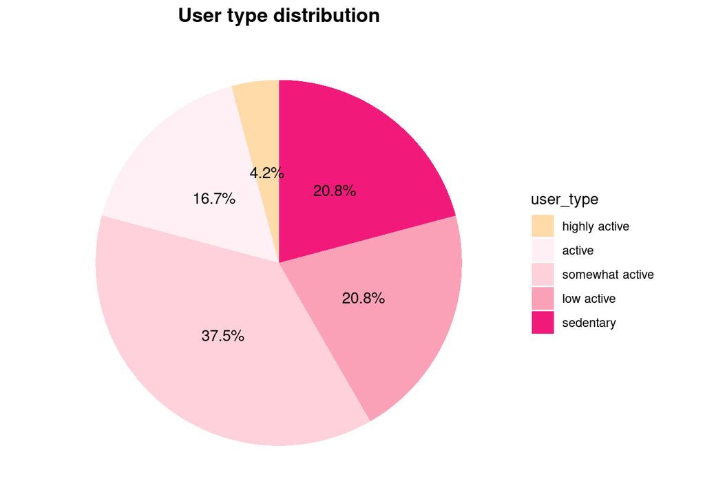

```r
user_type_percent %>%
  ggplot(aes(x="",y=total_percent, fill=user_type)) +
  geom_bar(stat = "identity", width = 1)+
  coord_polar("y", start=0)+
  theme_minimal()+
  theme(axis.title.x= element_blank(),
        axis.title.y = element_blank(),
        panel.border = element_blank(),
        panel.grid = element_blank(),
        axis.ticks = element_blank(),
        axis.text.x = element_blank(),
        plot.title = element_text(hjust = 0.5, size=14, face = "bold")) +
  scale_fill_manual(values = c("#FFDBAA","#FFF0F5", "#ffd1da", "#fba1b7", "#F11A7B")) +
  geom_text(aes(label = labels),
            position = position_stack(vjust = 0.5))+
  labs(title="User type distribution")
```

### **5.2 Correlations**

#### **5.2.1 Correlation between daily intensity and time in bed**

I am interested to find out if there is a correlation between the average daily intensity of the user and the total time they spend in bed. Hence, I will perform a correlation test.

*A Correlation test* is used to evaluate the association between two or more variables.

There are different methods used to perform correlation analysis. I am going to use the Pearson Correlation.

*Pearson correlation (r)*, which measures a linear dependence between two variables (x and y). It’s also known as a parametric correlation test because it depends to the distribution of the data. It can be used only when x and y are from normal distribution. The plot of y = f(x) is named the linear regression curve.

**Correlation formula**

In the formula below, * x and y are two vectors of length n * mx and my corresponds to the means of x and y, respectively.

**Pearson correlation formula**
$$r=∑(x−mx)(y−my)/√∑(x-mx)^2 ∑(y−my)^2$$
*mx* and *my* are the means of x and y variables.

The p-value (significance level) of the correlation can be determined:

1. by using the correlation coefficient table for the degrees of freedom : df=n−2, where n is the number of observation in x and y variables.
2. or by calculating the t value as follows:
   $$t=r/(√(1−r^2 )) * (√n−2)$$

In the case 2) the corresponding p-value is determined using t distribution table for df=n−2

**If the p-value is < 5%, then the correlation between x and y is significant.**

First, I visualize the data using a scatter plot.

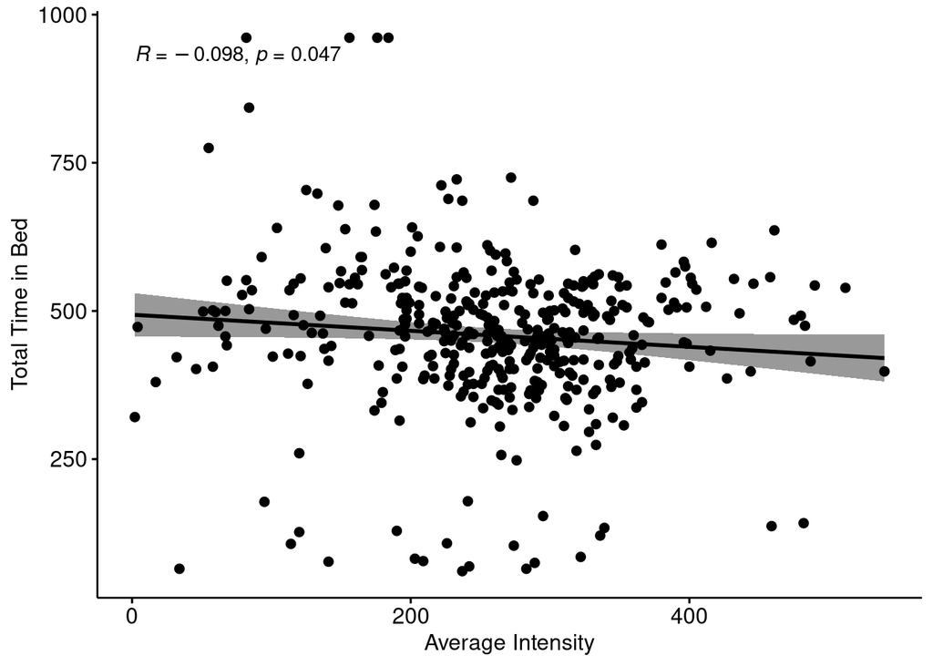

```r
ggscatter(avg_intensity_sleep, x = "avg_intensity" , y ="totaltimeinbed",
          add = "reg.line", conf.int = TRUE,
          cor.coef = TRUE, cor.method = "pearson",
          xlab ="Average Intensity" , ylab = "Total Time in Bed")
```

Visual inspection of the data normality using Q-Q plots (quantile-quantile plots). Q-Q plot draws the correlation between a given sample and the normal distribution.

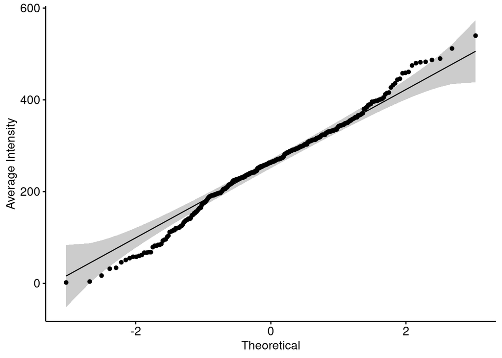

```r
# Average Intensity
ggqqplot(avg_intensity_sleep$avg_intensity, ylab = "Average Intensity")
```

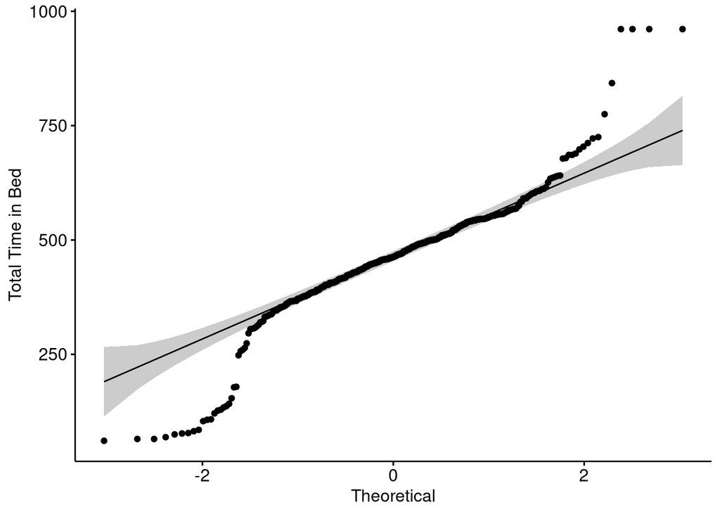

```r
# Total Time in Bed
ggqqplot(avg_intensity_sleep$totaltimeinbed, ylab = "Total Time in Bed")
```

Pearson Correlation Test between Average Intensity and Total Time in Bed:

```r
res <- cor.test(avg_intensity_sleep$avg_intensity, avg_intensity_sleep$totaltimeinbed,
                method = "pearson")
res
```

```
##
##  Pearson's product-moment correlation
##
## data:  avg_intensity_sleep$avg_intensity and avg_intensity_sleep$totaltimeinbed
## t = -1.9879, df = 408, p-value = 0.04749
## alternative hypothesis: true correlation is not equal to 0
## 95 percent confidence interval:
##  -0.192958030 -0.001104167
## sample estimates:
##       cor
## -0.097941
```

**In the result above:**

- t is the t-test statistic value (t = -1.9879),
- df is the degrees of freedom (df= 408),
- p-value is the significance level of the t-test (p-value = 0.04749).
- conf.int is the confidence interval of the correlation coefficient at 95% (conf.int = [-0.192958030, -0.001104167]);
- sample estimates is the correlation coefficient (Cor.coeff = -0.097941).

*The p-value of the test is 0.04749, which is less than the significance level alpha = 0.05. We can conclude that Average Intensity and Total Time in Bed are correlated with a correlation coefficient of -0.097941 and p-value of 0.04749.*

**There is a slight correlation between intensity and total time in bed. The chart shows that the higher the average intensity throughout the day, the less time is spent in bed. However, the correlation is not strong enough to conclude that intensity level is the cause behind time spent in bed. Bellabeat could suggest activities for the users throughout the day to reduce time wasted in bed.**

#### **5.2.2 Further Correlations**

I will now try to identify if there are any correlations between daily steps and sleep as well as calories.

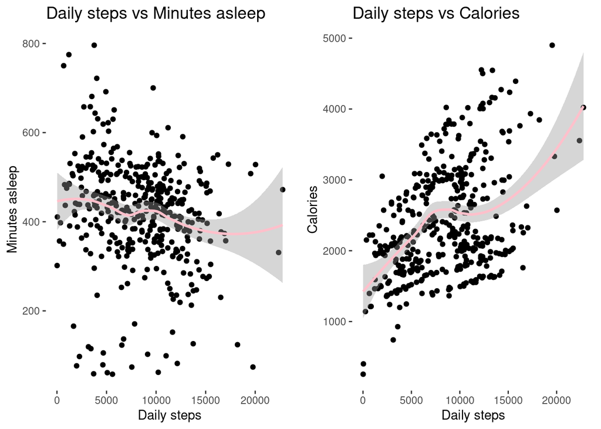

```r
ggarrange(
  ggplot(daily_activity_sleep, aes(x=totalsteps, y=totalminutesasleep))+
    geom_jitter() +
    geom_smooth(color = "pink") +
    labs(title = "Daily steps vs Minutes asleep", x = "Daily steps", y= "Minutes asleep") +
    theme(panel.background = element_blank(),
          plot.title = element_text(size=14)),
  ggplot(daily_activity_sleep, aes(x=totalsteps, y=calories))+
    geom_jitter() +
    geom_smooth(color = "pink") +
    labs(title = "Daily steps vs Calories", x = "Daily steps", y= "Calories") +
    theme(panel.background = element_blank(),
          plot.title = element_text(size=14))
)
```

### **5.3 Steps throughout the day**

As I go further into the analysis, I want to know precisely when users are more active throughout the day.

First, I will seperate the date and time from the date_time column:

```r
hourly_steps <- hourly_steps %>%
  separate(date_time, into = c("date", "time"), sep= " ") %>%
  mutate(date = ymd(date))
head(hourly_steps)
```

```
## # A tibble: 6 × 4
##           id date       time     steptotal
##        <dbl> <date>     <chr>        <dbl>
## 1 1503960366 2016-04-12 <NA>           373
## 2 1503960366 2016-04-12 01:00:00       160
## 3 1503960366 2016-04-12 02:00:00       151
## 4 1503960366 2016-04-12 03:00:00         0
## 5 1503960366 2016-04-12 04:00:00         0
## 6 1503960366 2016-04-12 05:00:00         0
```

Now, I will plot the average steps taken by a user throughout the day.

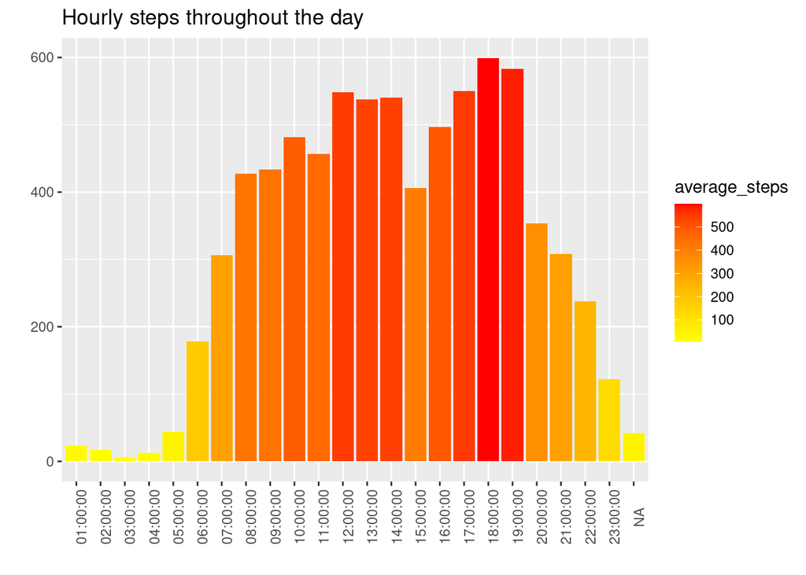

```r
hourly_steps %>%
  group_by(time) %>%
  summarize(average_steps = mean(steptotal)) %>%
  ggplot() +
  geom_col(mapping = aes(x=time, y = average_steps, fill = average_steps)) +
  labs(title = "Hourly steps throughout the day", x="", y="") +
  scale_fill_gradient(low = "yellow", high = "red")+
  theme(axis.text.x = element_text(angle = 90))
```

**Users are more active from 8 am to 7 pm, as can be seen. Taking extra steps between 5 and 7 in the evening and over lunch from 12 to 2 in the afternoon.**

### **5.4 Use of smart device**

I am interested in finding out how frequently the users in our sample use their device now that we have observed certain trends in activity, sleep, and calories burned. By doing so, we can plan our marketing approach and determine which features would make the application more useful. Knowing that the date interval is 31 days, we will divide our sample into three categories and determine the proportion of users who use their smart device on a daily basis:

```r
daily_use <- daily_activity_sleep %>%
  group_by(id) %>%
  summarize(days_used=sum(n())) %>%
  mutate(usage = case_when(
    days_used >= 1 & days_used <= 10 ~ "low use",
    days_used >= 11 & days_used <= 20 ~ "moderate use",
    days_used >= 21 & days_used <= 31 ~ "high use",
  ))

head(daily_use)
```

```
## # A tibble: 6 × 3
##           id days_used usage
##        <dbl>     <int> <chr>
## 1 1503960366        25 high use
## 2 1644430081         4 low use
## 3 1844505072         3 low use
## 4 1927972279         5 low use
## 5 2026352035        28 high use
## 6 2320127002         1 low use
```

Sorting them by percentage:

```r
daily_use_percent <- daily_use %>%
  group_by(usage) %>%
  summarise(total = n()) %>%
  mutate(totals = sum(total)) %>%
  group_by(usage) %>%
  summarise(total_percent = total / totals) %>%
  mutate(labels = scales::percent(total_percent))

daily_use_percent$usage <- factor(daily_use_percent$usage, levels = c("high use", "moderate use", "low use"))

head(daily_use_percent)
```

```
## # A tibble: 3 × 3
##   usage        total_percent labels
##   <fct>                <dbl> <chr>
## 1 high use             0.5   50%
## 2 low use              0.375 38%
## 3 moderate use         0.125 12%
```

Visualizing the results:

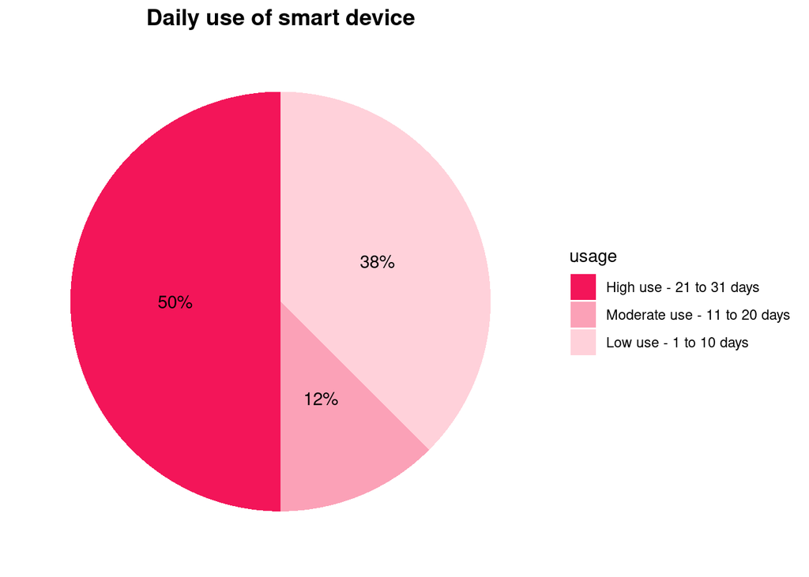

```r
daily_use_percent %>%
  ggplot(aes(x="",y=total_percent, fill=usage)) +
  geom_bar(stat = "identity", width = 1)+
  coord_polar("y", start=0)+
  theme_minimal()+
  theme(axis.title.x= element_blank(),
        axis.title.y = element_blank(),
        panel.border = element_blank(),
        panel.grid = element_blank(),
        axis.ticks = element_blank(),
        axis.text.x = element_blank(),
        plot.title = element_text(hjust = 0.5, size=14, face = "bold")) +
  geom_text(aes(label = labels),
            position = position_stack(vjust = 0.5))+
  scale_fill_manual(values = c("#F31559","#FBA1B7","#FFD1DA"),
                    labels = c("High use - 21 to 31 days",
                               "Moderate use - 11 to 20 days",
                               "Low use - 1 to 10 days"))+
  labs(title="Daily use of smart device")
```

```r
#Merging daily activity and use
daily_use_merged <- merge(daily_activity, daily_use, by=c ("id"))
head(daily_use_merged)
```

```
##           id       date totalsteps totaldistance trackerdistance
## 1 1503960366 2016-05-07      11992          7.71            7.71
## 2 1503960366 2016-05-06      12159          8.03            8.03
## 3 1503960366 2016-05-01      10602          6.81            6.81
## 4 1503960366 2016-04-30      14673          9.25            9.25
## 5 1503960366 2016-04-12      13162          8.50            8.50
## 6 1503960366 2016-04-13      10735          6.97            6.97
##   loggedactivitiesdistance veryactivedistance moderatelyactivedistance
## 1                        0               2.46                     2.12
## 2                        0               1.97                     0.25
## 3                        0               2.29                     1.60
## 4                        0               3.56                     1.42
## 5                        0               1.88                     0.55
## 6                        0               1.57                     0.69
##   lightactivedistance sedentaryactivedistance veryactiveminutes
```

[output cut: 20 more lines]

```r
#Segregating total activity by percentage
minutes_worn <- daily_use_merged %>%
  mutate(total_minutes_worn = veryactiveminutes+fairlyactiveminutes+lightlyactiveminutes+sedentaryminutes)%>%
  mutate (percent_minutes_worn = (total_minutes_worn/1440)*100) %>%
  mutate (worn = case_when(
    percent_minutes_worn == 100 ~ "All day",
    percent_minutes_worn < 100 & percent_minutes_worn >= 50~ "More than half day",
    percent_minutes_worn < 50 & percent_minutes_worn > 0 ~ "Less than half day"
  ))

head(minutes_worn)
```

```
##           id       date totalsteps totaldistance trackerdistance
## 1 1503960366 2016-05-07      11992          7.71            7.71
## 2 1503960366 2016-05-06      12159          8.03            8.03
## 3 1503960366 2016-05-01      10602          6.81            6.81
## 4 1503960366 2016-04-30      14673          9.25            9.25
## 5 1503960366 2016-04-12      13162          8.50            8.50
## 6 1503960366 2016-04-13      10735          6.97            6.97
##   loggedactivitiesdistance veryactivedistance moderatelyactivedistance
## 1                        0               2.46                     2.12
## 2                        0               1.97                     0.25
## 3                        0               2.29                     1.60
## 4                        0               3.56                     1.42
## 5                        0               1.88                     0.55
## 6                        0               1.57                     0.69
##   lightactivedistance sedentaryactivedistance veryactiveminutes
```

[output cut: 20 more lines]

**To be more specific, we want to know how long consumers spend using their device each day. In order to filter results by daily use of the device as well, we are going to merge daily_use with daily_activity in a new constructed data frame.**

We must construct a new data frame that divides the total daily minutes users spent wearing the device into three categories:

- All day - device was worn all day.
- More than half day - device was worn more than half of the day.
- Less than half day - device was worn less than half of the day.

```r
minutes_worn_percent<- minutes_worn%>%
  group_by(worn) %>%
  summarise(total = n()) %>%
  mutate(totals = sum(total)) %>%
  group_by(worn) %>%
  summarise(total_percent = total / totals) %>%
  mutate(labels = scales::percent(total_percent))


minutes_worn_highuse <- minutes_worn%>%
  filter (usage == "high use")%>%
  group_by(worn) %>%
  summarise(total = n()) %>%
  mutate(totals = sum(total)) %>%
  group_by(worn) %>%
  summarise(total_percent = total / totals) %>%
  mutate(labels = scales::percent(total_percent))

minutes_worn_moduse <- minutes_worn%>%
  filter(usage == "moderate use") %>%
  group_by(worn) %>%
  summarise(total = n()) %>%
  mutate(totals = sum(total)) %>%
  group_by(worn) %>%
  summarise(total_percent = total / totals) %>%
  mutate(labels = scales::percent(total_percent))

minutes_worn_lowuse <- minutes_worn%>%
  filter (usage == "low use") %>%
  group_by(worn) %>%
  summarise(total = n()) %>%
  mutate(totals = sum(total)) %>%
  group_by(worn) %>%
  summarise(total_percent = total / totals) %>%
  mutate(labels = scales::percent(total_percent))

#Sorting by percentage of time worn
minutes_worn_highuse$worn <- factor(minutes_worn_highuse$worn, levels = c("All day", "More than half day", "Less than half day"))
minutes_worn_percent$worn <- factor(minutes_worn_percent$worn, levels = c("All day", "More than half day", "Less than half day"))
minutes_worn_moduse$worn <- factor(minutes_worn_moduse$worn, levels = c("All day", "More than half day", "Less than half day"))
minutes_worn_lowuse$worn <- factor(minutes_worn_lowuse$worn, levels = c("All day", "More than half day", "Less than half day"))

head(minutes_worn_percent)
```

```
## # A tibble: 3 × 3
##   worn               total_percent labels
##   <fct>                      <dbl> <chr>
## 1 All day                   0.365  36%
## 2 Less than half day        0.0351 4%
## 3 More than half day        0.600  60%
```

```r
head(minutes_worn_highuse)
```

```
## # A tibble: 3 × 3
##   worn               total_percent labels
##   <fct>                      <dbl> <chr>
## 1 All day                   0.0676 6.8%
## 2 Less than half day        0.0432 4.3%
## 3 More than half day        0.889  88.9%
```

```r
head(minutes_worn_moduse)
```

```
## # A tibble: 3 × 3
##   worn               total_percent labels
##   <fct>                      <dbl> <chr>
## 1 All day                    0.267 27%
## 2 Less than half day         0.04  4%
## 3 More than half day         0.693 69%
```

```r
head(minutes_worn_lowuse)
```

```
## # A tibble: 3 × 3
##   worn               total_percent labels
##   <fct>                      <dbl> <chr>
## 1 All day                   0.802  80%
## 2 Less than half day        0.0224 2%
## 3 More than half day        0.175  18%
```

Visualizing the results:

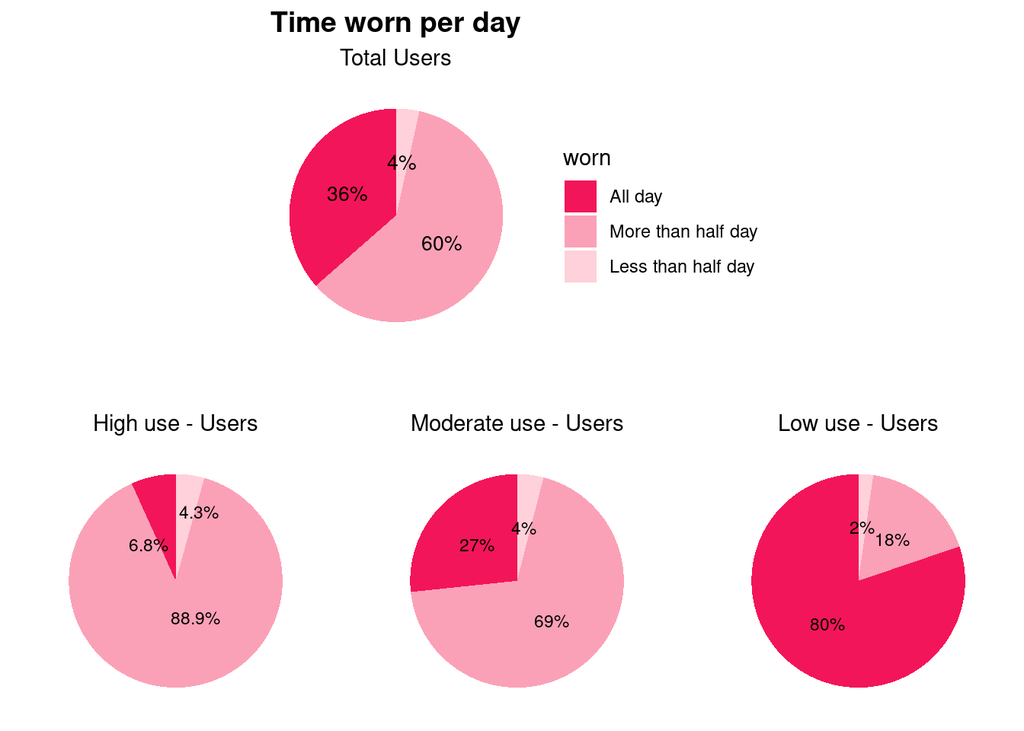

```r
ggarrange(
  ggplot(minutes_worn_percent, aes(x="",y=total_percent, fill=worn)) +
    geom_bar(stat = "identity", width = 1)+
    coord_polar("y", start=0)+
    theme_minimal()+
    theme(axis.title.x= element_blank(),
          axis.title.y = element_blank(),
          panel.border = element_blank(),
          panel.grid = element_blank(),
          axis.ticks = element_blank(),
          axis.text.x = element_blank(),
          plot.title = element_text(hjust = 0.5, size=14, face = "bold"),
          plot.subtitle = element_text(hjust = 0.5)) +
    scale_fill_manual(values = c("#F31559", "#FBA1B7", "#FFD1DA"))+
    geom_text(aes(label = labels),
              position = position_stack(vjust = 0.5), size = 3.5)+
    labs(title="Time worn per day", subtitle = "Total Users"),
  ggarrange(
    ggplot(minutes_worn_highuse, aes(x="",y=total_percent, fill=worn)) +
      geom_bar(stat = "identity", width = 1)+
      coord_polar("y", start=0)+
      theme_minimal()+
      theme(axis.title.x= element_blank(),
            axis.title.y = element_blank(),
            panel.border = element_blank(),
            panel.grid = element_blank(),
            axis.ticks = element_blank(),
            axis.text.x = element_blank(),
            plot.title = element_text(hjust = 0.5, size=14, face = "bold"),
            plot.subtitle = element_text(hjust = 0.5),
            legend.position = "none")+
      scale_fill_manual(values = c("#F31559", "#FBA1B7", "#FFD1DA"))+
      geom_text_repel(aes(label = labels),
                      position = position_stack(vjust = 0.5), size = 3)+
      labs(title="", subtitle = "High use - Users"),
    ggplot(minutes_worn_moduse, aes(x="",y=total_percent, fill=worn)) +
      geom_bar(stat = "identity", width = 1)+
      coord_polar("y", start=0)+
      theme_minimal()+
      theme(axis.title.x= element_blank(),
            axis.title.y = element_blank(),
            panel.border = element_blank(),
            panel.grid = element_blank(),
            axis.ticks = element_blank(),
            axis.text.x = element_blank(),
            plot.title = element_text(hjust = 0.5, size=14, face = "bold"),
            plot.subtitle = element_text(hjust = 0.5),
            legend.position = "none") +
      scale_fill_manual(values = c("#F31559", "#FBA1B7", "#FFD1DA"))+
      geom_text(aes(label = labels),
                position = position_stack(vjust = 0.5), size = 3)+
      labs(title="", subtitle = "Moderate use - Users"),
    ggplot(minutes_worn_lowuse, aes(x="",y=total_percent, fill=worn)) +
      geom_bar(stat = "identity", width = 1)+
      coord_polar("y", start=0)+
      theme_minimal()+
      theme(axis.title.x= element_blank(),
            axis.title.y = element_blank(),
            panel.border = element_blank(),
            panel.grid = element_blank(),
            axis.ticks = element_blank(),
            axis.text.x = element_blank(),
            plot.title = element_text(hjust = 0.5, size=14, face = "bold"),
            plot.subtitle = element_text(hjust = 0.5),
            legend.position = "none") +
      scale_fill_manual(values = c("#F31559", "#FBA1B7", "#FFD1DA"))+
      geom_text(aes(label = labels),
                position = position_stack(vjust = 0.5), size = 3)+
      labs(title="", subtitle = "Low use - Users"),
    ncol = 3),
  nrow = 2)
```

## **6.Conclusions**

### **6.1 Target Audience**

It isn’t specified whether the sample data includes women and Bellabeat’s app and campaign are mainly directed towards women. I suggest using a more relevant and accurate dataset to derive insights directly related to women as their health metrics are different from their male counterparts.

### **6.3 Recommendations**

Bellabeat’s mission is to empower women by providing them with the data to discover themselves.

1. **Notifications:**
- The app can send daily notifications to remind users to take their recommended 8,000 steps, specially between 5 and 7 in the evening and over lunch from 12 to 2 in the afternoon.
- It can send notifications to remind low and moderate users of their daily activities as well as send them information on their daily steps, activities and sleep patterns.
2. **Posts and Articles:**

Since Bellabeat’s mission is to empower women by providing them with the relevant knowledge they need to discover and take care of themselves, then the app should have posts and articles about:

- Women’s health
- Calorie consumption and diet suggestions
- Activity suggestions and routines
- The importance of sleep and how to improve it
- Etc..

This way, it can empower them with the knowledge they need to take their health into their own hands.

3. **Reward System:** Bellabeat can create a reward system for women that use the app more frequently and are more consistent with their health by incentivizing them with discounts and rewards. This will encourage women to use the app more while keeping them healthy.